# WUM - Projekt 1 - inżynieria cech, wstępne modelowanie

Konrad Komisarczyk, Patryk Wrona

31.03.2020

# Ładowanie danych i usunięcie danych nadmiarowych

```r
data <- read.csv("cervical-cancer_csv.csv")

factorize <- function(data, indices) {
  for (i in indices) {
    data[[i]] <- as.factor(data[[i]])
  }
  data
}

data <- factorize(data, c(5, 8, 10, 12, 14:25, 29:36))
```

Możemy usunąć kolumny, o których stwierdziliśmy na poprzednim kamieniu milowym, że są nadmiarowe:

```r
data <- data %>%
  select(-Smokes,
         -Hormonal.Contraceptives,
         -IUD,
         -STDs,
         -Dx,
         -STDs.HPV, # to niekoniecznie usuwać, ale może spróbujmy
         -STDs..Number.of.diagnosis, # bardzo podobne wartości do STDs, rożnią sie tylko w kilku miejscach, może usunąć żeby nie spowodowało to jakiegoś nadmiernego dopasowania
         -STDs.condylomatosis,
         -Hinselmann,
         -Schiller,
         -Citology)

colnames(data)
```

```
##  [1] "Age"
##  [2] "Number.of.sexual.partners"
##  [3] "First.sexual.intercourse"
##  [4] "Num.of.pregnancies"
##  [5] "Smokes..years."
##  [6] "Smokes..packs.year."
##  [7] "Hormonal.Contraceptives..years."
##  [8] "IUD..years."
##  [9] "STDs..number."
## [10] "STDs.cervical.condylomatosis"
## [11] "STDs.vaginal.condylomatosis"
## [12] "STDs.vulvo.perineal.condylomatosis"
## [13] "STDs.syphilis"
## [14] "STDs.pelvic.inflammatory.disease"
## [15] "STDs.genital.herpes"
## [16] "STDs.molluscum.contagiosum"
## [17] "STDs.AIDS"
## [18] "STDs.HIV"
## [19] "STDs.Hepatitis.B"
## [20] "STDs..Time.since.first.diagnosis"
## [21] "STDs..Time.since.last.diagnosis"
## [22] "Dx.Cancer"
## [23] "Dx.CIN"
## [24] "Dx.HPV"
## [25] "Biopsy"
```

# Zastąpienie braków danych

## Znaczące braki danych

Braki danych w tych kolumnach oznaczają, że pacjentka nie miała jeszcze żadnej diagnozy. Zastępujemy je wartością `-1`.

```r
data$STDs..Time.since.first.diagnosis <-
  ifelse(is.na(data$STDs..Time.since.first.diagnosis),
         -1,
         data$STDs..Time.since.first.diagnosis)

data$STDs..Time.since.last.diagnosis <-
  ifelse(is.na(data$STDs..Time.since.last.diagnosis),
         -1,
         data$STDs..Time.since.last.diagnosis)
```

## Porównanie metod

Porównamy dla każdej zmiennej jak sprawują się w zastępowaniu jej poszczególne metody z pakietu `mice` tworząc wykres RMSE dla nich.

Testy przeprowadzimy na sztucznie wygenerowanych brakach danych w tej części zbioru, która nie ma braków.

```r
cancer_cleared <- data %>%
  na.omit() %>%
  select(-Biopsy)
```

Wykorzystamy następującą funkcję do generowania wykresów dla poszczególnych zmiennych:

```r
compare_methods <- function(variable) {

  # zastępujemy 10% zmiennych brakami danych
  cancer_na <- cancer_cleared
  cancer_na[[variable]] <- unlist(missForest::prodNA(cancer_cleared[variable], noNA = 0.1))


  error_pmm <- numeric(0)
  error_norm <- numeric(0)
  error_mean <- numeric(0)
  error_qua <- numeric(0)
  error_crt <- numeric(0)
  error_rf <- numeric(0)

  RMSD <- function(data_imputed) {
    sqrt(mean((cancer_cleared[[variable]] - data_imputed[[variable]]) ^ 2))
  }

  for (i in 1:6) {
    # 1 Predictive mean matching
    data_imputed <- mice(cancer_na, m = 2, method = "pmm", maxit = 10, printFlag = FALSE) %>% complete(2)
    error_pmm <- c(error_pmm, RMSD(data_imputed))

    # 2  Bayesian linear regression
    data_imputed <- mice(cancer_na, m = 2, method = "norm", maxit = 10, printFlag = FALSE) %>% complete(2)
    error_norm <- c(error_norm, RMSD(data_imputed))

    # 3  Unconditional mean imputation
    data_imputed <- mice(cancer_na, m = 2, method = "mean", maxit = 10, printFlag = FALSE) %>% complete(2)
    data_imputed[[variable]] <- round(data_imputed[[variable]])
    error_mean <- c(error_mean, RMSD(data_imputed))

    # 4  Imputation of quadratic terms
    data_imputed <- mice(cancer_na, m = 2, method = "quadratic", maxit = 10, printFlag = FALSE) %>% complete(2)
    # data_imputed_2$Number.of.sexual.partners <- round(data_imputed_2$Number.of.sexual.partners)
    error_qua <- c(error_qua, RMSD(data_imputed))

    # 5 Classification and regression trees
    data_imputed <- mice(cancer_na, m = 2, method = "cart", maxit = 10, printFlag = FALSE) %>% complete(2)
    # data_imputed_2$Number.of.sexual.partners <- round(data_imputed_2$Number.of.sexual.partners)
    error_crt <- c(error_crt, RMSD(data_imputed))

    # 6 Random forest imputations
    data_imputed <- mice(cancer_na, m = 2, method = "rf", maxit = 10, printFlag = FALSE) %>% complete(2)
    # data_imputed_2$Number.of.sexual.partners <- round(data_imputed_2$Number.of.sexual.partners)
    error_rf <- c(error_rf, RMSD(data_imputed))
  }


  plot(error_pmm,
       col = "orange",
       main = paste0("Imputacja danych ", variable),
       xlab = "iteration", ylab = "RMSE",
       ylim = c(round(min(error_pmm, error_norm, error_mean, error_qua,
                  error_crt, error_rf),1),
              round(max(error_pmm, error_norm, error_mean, error_qua,
                  error_crt, error_rf),1)))
  lines(error_pmm, col = "orange")

  points(error_norm, col = "blue", add = TRUE)
  lines(error_norm, col = "blue", add = TRUE)

  points(error_mean, col = "red", add = TRUE)
  lines(error_mean, col = "red", add = TRUE)

  points(error_qua, col = "yellow", add = TRUE)
  lines(error_qua, col = "yellow", add = TRUE)

  points(error_crt, col = "purple", add = TRUE)
  lines(error_crt, col = "purple", add = TRUE)

  points(error_rf, col = "black", add = TRUE)
  lines(error_rf, col = "black", add = TRUE)

  legend("topleft",
         legend = c("pmm", "Bayes", "mean", "quad terms", "CRT", "RF"),
         col = c("orange", "blue", "red", "yellow", "purple", "black"),
         lty = 1, cex = 0.6)

}
```

Sprawdzimy

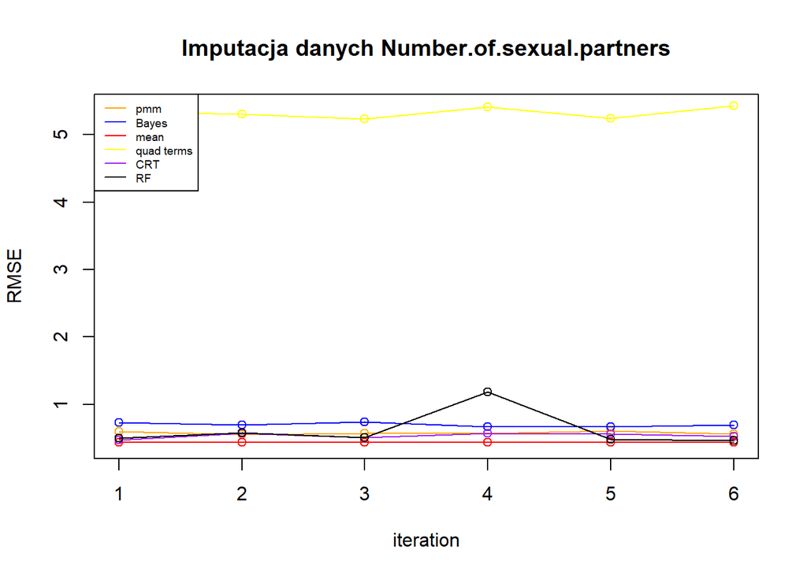

```r
compare_methods("Number.of.sexual.partners")
```

Dla zmiennej Number.of.sexual.partners najlepsza metoda: **mean**.

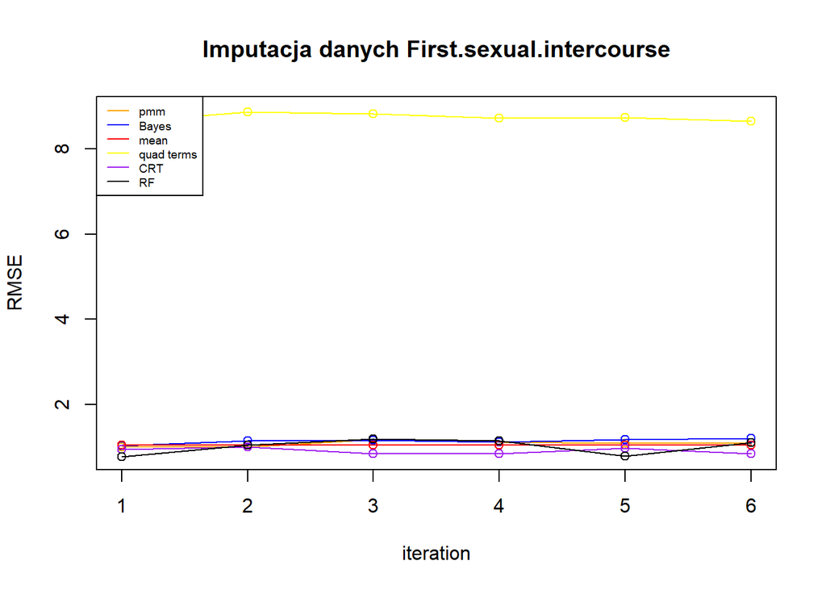

```r
compare_methods("First.sexual.intercourse")
```

Dla zmiennej First.sexual.intercourse najlepsza metoda: **CRT**.

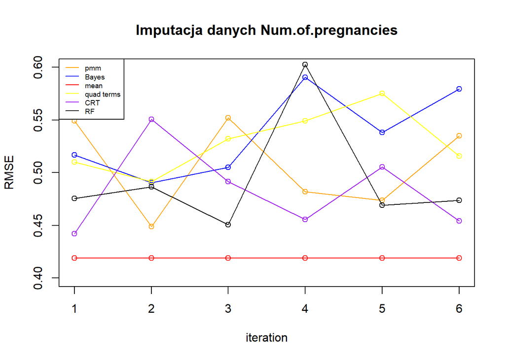

```r
compare_methods("Num.of.pregnancies")
```

Dla zmiennej Num.of.pregnancies najlepsza metoda: **mean**.

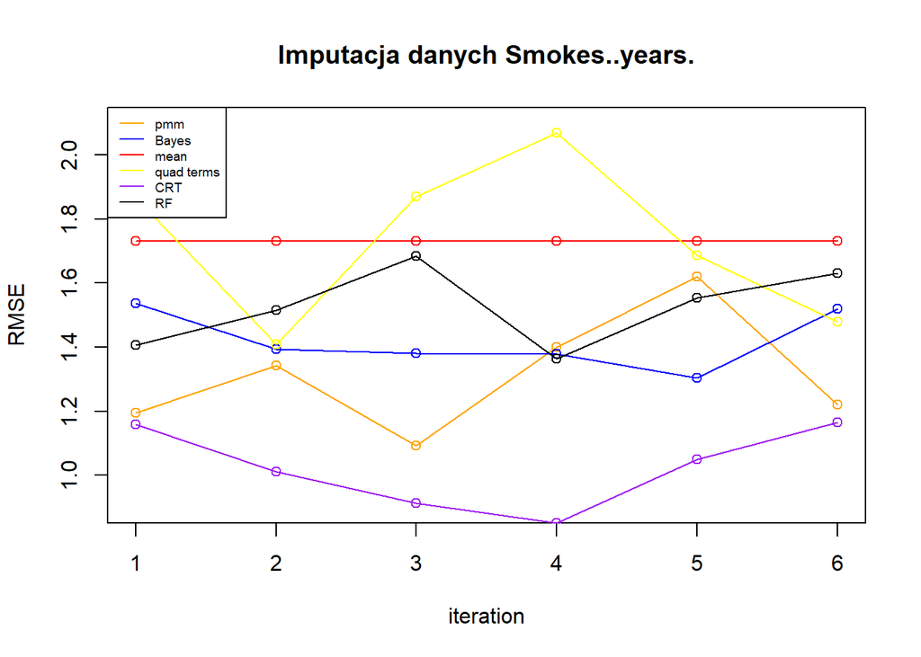

```r
compare_methods("Smokes..years.")
```

Dla zmiennej Smokes..years. najlepsza metoda: **CRT**.

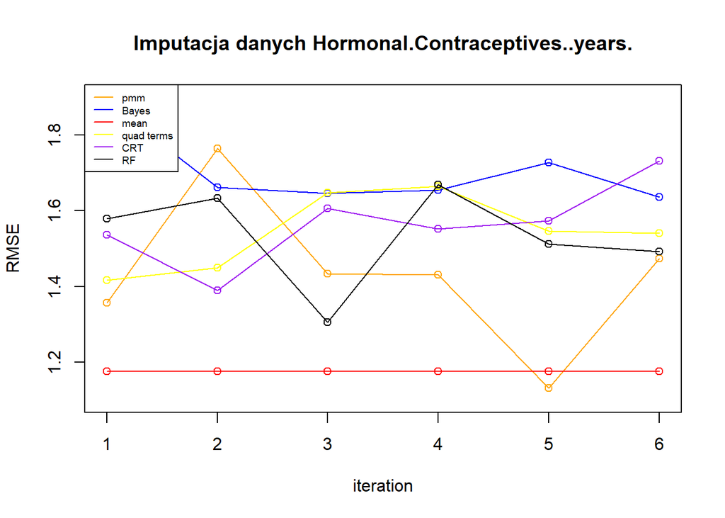

```r
compare_methods("Hormonal.Contraceptives..years.")
```

Dla zmiennej Hormonal.Contraceptives..years. najlepsza metoda: **mean**.

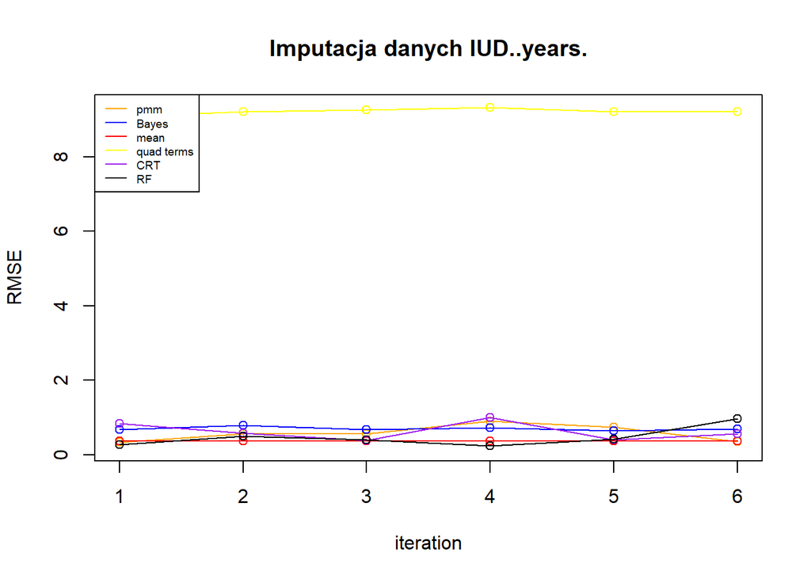

```r
compare_methods("IUD..years.")
```

Dla zmiennej IUD..years.. najlepsza metoda: **mean**.

## Imputacja braków danych

Wykorzystamy zdobydą wiedzę o metodach, które są najlepsze do imputacji poszczególnych zmiennych. Podsumowując wszystkie metody:

- Number.of.sexual.partners -> **mean**
- First.sexual.intercourse -> **CRT**
- Num.of.pregnancies -> **mean**
- Smokes..years.. -> **CART**
- Hormonal.Contraceptives..years. -> **mean**
- IUD..years.. -> **mean**

W związku z tym wybieramy najlepszą metodę do imputowania danych, czyli **mean**, gdyż okazała się być najlepsza w większości przypadków.

```r
aux <- data

completeFun <- function(data, desiredCols) {
  completeVec <- complete.cases(data[, desiredCols])
  return(data[completeVec, ])
}

# wyrzucanie zbędnych wierszy będących NA z innych zmiennych:
aux <- completeFun(aux, 9:25)

# imputacja danych
aux <- mice(aux, m = 2, method = "mean", maxit = 10, printFlag = FALSE) %>% complete(2)


# zaokrąglanie, gdyż wynikiem mean jest średnia:
aux[[2]] <- round(aux[[2]])
aux[[3]] <- round(aux[[3]])
aux[[4]] <- round(aux[[4]])
aux[[5]] <- round(aux[[5]])
aux[[7]] <- round(aux[[7]])
aux[[8]] <- round(aux[[8]])

data <- aux
```

# Encoding zmiennych kategorycznych

Wszystkie zmienne kategoryczne w naszych danych mają dwa poziomy `0` i `1`. Są więc już zapisane w postaci one hot encoding.

# Wstępne modelowanie

Wykorzystamy modele klasyfikacyjne dla zmiennej celu Biopsy. Użyjemy przykładowego algorytmu uczenia maszynowego klasyfikacji: - Random Forest

## Podział danych na zbiory testowe i treningowe

W zbiorze treningowym mieścimy losowych 80% obserwacji, a w zbiorze testowym losowych 20%.

```r
# wybranie kolumny celu(target) i wszystkich innych kolumn nie będących kolumną celu (characteristics)

levels(data$Biopsy) <- c("NO", "YES")

characteristics <- data %>%
  select(-Biopsy)
target <- data$Biopsy

# podział danych na treningowe i testowe:

wiersze_treningowe <- createDataPartition(target, p = 0.8, list= FALSE)
char_train <- characteristics[wiersze_treningowe, ]
target_train <- as.factor(target[wiersze_treningowe] )
char_test <- characteristics[-wiersze_treningowe, ]
target_test <- as.factor(target[-wiersze_treningowe])
```

## Cross Validation

```r
ctrlr <- trainControl(method = "repeatedcv",
                      classProbs = TRUE,
                      repeats = 7,
                      number = 7
)
```

## Random Forest

### Random forest - trenowanie modelu

Zastosujemy algorytm Random Forest w celu klasyfikacji zmiennej celu.

```r
rfModel <- train(x = char_train,
               y = target_train,
               method = "rf",
               ntree = 100,
               tuneLength = 5,
               trControl = ctrlr)
```

### Confusion matrix

```r
confusionMatrix(predict(rfModel, char_test),
                target_test,
                positive = "YES")
```

```
## Confusion Matrix and Statistics
##
##           Reference
## Prediction  NO YES
##        NO  136  10
##        YES   0   0
##
##                Accuracy : 0.9315
##                  95% CI : (0.8776, 0.9667)
##     No Information Rate : 0.9315
##     P-Value [Acc > NIR] : 0.583092
##
##                   Kappa : 0
##
##  Mcnemar's Test P-Value : 0.004427
##
##             Sensitivity : 0.00000
##             Specificity : 1.00000
##          Pos Pred Value :     NaN
##          Neg Pred Value : 0.93151
##              Prevalence : 0.06849
##          Detection Rate : 0.00000
##    Detection Prevalence : 0.00000
##       Balanced Accuracy : 0.50000
##
##        'Positive' Class : YES
##
```

Accuracy wynosi około 0.93. Jest to dość wysoki wynik. Niestety, wynika on z tego, że nasz model przewidywał tylko, że ktoś nie jest chory, co dawało mu dobre rezultaty, bo przecież większość pacjentek nie była chora. W przyszłości musimy popracować nad doborem modelu, gdyż wstępne modelowanie na ten moment nie dało oczekiwanych efektów.

W przypadku naszego problemu diagnozujemy raka. Zakładając, że wynik naszego modelu nie byłby ostatecznym werdyktem, to istotne jest dla nas, żeby zdiagnozować w miarę możliwości wszystkie przypadki. False Positives mogą nie być dla nas takie złe, jak False Negatives. Istotną dla oceny modelu miarą zatem jest dla nas Sensitivity, czyli True Positive Rate - jaka część pacjentek chorych została zaklasyfikowana jako chore - chcemy, żeby miara była bliska 1.

### Krzywa ROC

Zbadamy teraz Receiver Operating Characteristic Curve ( ROC ) naszego modelu Random Forest:

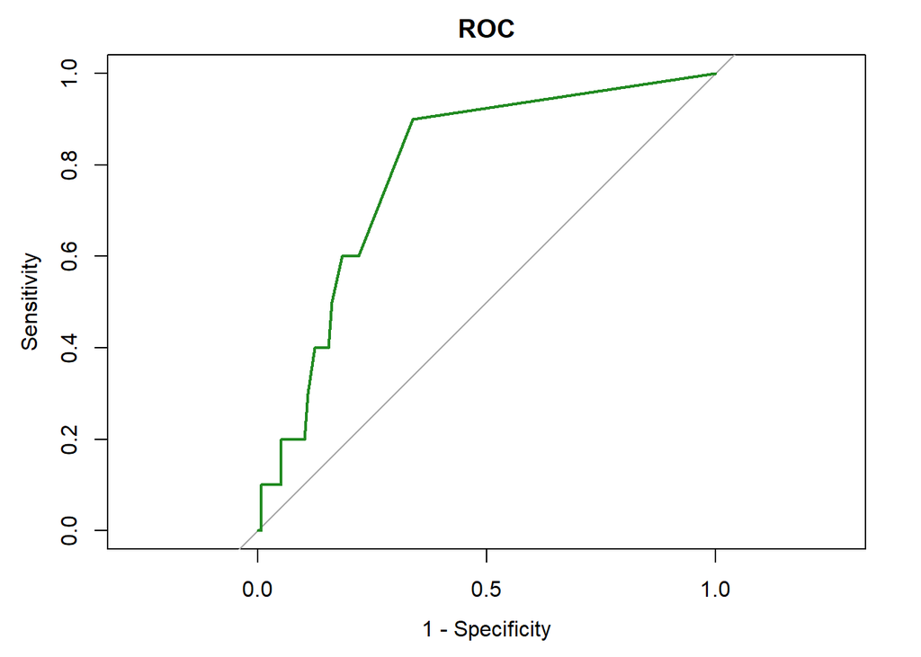

```r
ROCCurve <- roc(target_test,
                predict(rfModel, char_test, type = "prob")[, "YES"],
                ci = TRUE)
plot.roc(ROCCurve,
         legacy.axes = TRUE,
         main="ROC",
         percent=TRUE,
         col = "#228B22") # forest green
```

### Area Under Curve

```r
auc(ROCCurve)
```

```
## Area under the curve: 0.7879
```

AUC rzędu 0.7-0.8 jest średnim wynikiem, ale w miarę akceptowalnym. W algorytmie Random Forest zastosowaliśmy liczbę drzew równą 100, gdyż dla kilku drzew osiągaliśmy AUC w okolicach 0.5-0.6, co nie jest satysfakcjonującym wynikiem. Ponadto, AUC 0.5 przypiuje się modelowi losowemu.

W przyszłm punkcie kontrolnym postaramy się w miarę możliwości zminimalizować ( jeśli nie wyeliminować) False Negatives, aby nasz model mógł diagnozować rzeczywistego raka bezbłędnie.